# Caso práctico

Paula García González

2025-01-22

# Sitio de estudio

## Descripción del lugar

Nos encontramos en el **Parque Nacional de Sierra Nevada**, en la provincia de Granada. Sierra Nevada es una formación montañosa situada en España, que forma parte de las cordilleras Béticas, específicamente del sistema Penibético. Se extiende entre las provincias de Granada y Almería y destaca por ser el macizo más alto de Europa occidental después de los Alpes. Su punto más elevado es el pico Mulhacén, con 3479 metros sobre el nivel del mar. En 1986, la Unesco la reconoció como Reserva de la Biosfera, y en 1989 gran parte de su superficie fue designada como parque natural. Posteriormente, en 1999, una extensa área fue declarada parque nacional debido a su riqueza botánica, paisajística y natural (Blanca et al., 1998).

[interactive chart not shown]

Mapa de localización de la zona de estudio

# Flora

En Sierra Nevada se han identificado más de 2.100 especies de plantas vasculares, convirtiéndola en una de las regiones con mayor diversidad y riqueza de flora en el Mediterráneo occidental. Entre estas especies, destaca un elevado número de endemismos exclusivos de la zona. Además, se han catalogado 116 taxones con distribución limitada y en riesgo de extinción, lo que resalta la importancia de proteger esta biodiversidad. La singularidad de la flora local también se refleja en la presencia de numerosas especies ibero-norteafricanas, que representan entre un 10% y un 12% del total (Blanca et al., 1998), incluyendo ejemplares como *Adenocarpus decorticans*, *Arenaria pungens*, *Crocus nevadensis*, *Draba hispanica*, *Festuca scariosa*, *Genista umbellata*, *Hormathophylla spinosa*, *Lonicera arborea*, *Ononis speciosa*, *Ranunculus granatensis*, *Stipa tenacissima* y *Thymus serpylloides subsp. gadorensis*.

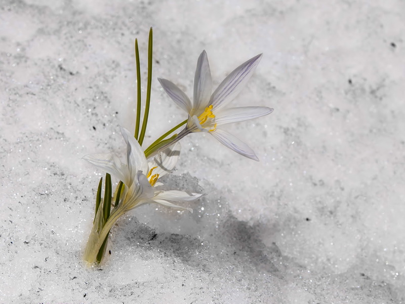

*Crocus nevadensis* en flor. De [floradeandalucia.es](https://www.florandalucia.es/index.php/crocus-nevadensis)

# Fauna (artrópodos)

Sierra Nevada alberga 146 taxones estrictamente endémicos, que incluyen 128 especies y 18 subespecies, además de 35 subendémicos, compuestos por 29 especies y 6 subespecies. Entre ellos se encuentran seis géneros únicos de esta región: *Roeweritta* (Opiliones), *Nevada* (Trombidiiformes), *Eulithinus* (Dermaptera), *Baetica* (Orthoptera), *Montanacalles* (Coleoptera) y *Pseudorhaconotus* (Hymenoptera), lo que resalta la singularidad biológica de esta área (Tinaut et al., 2024).

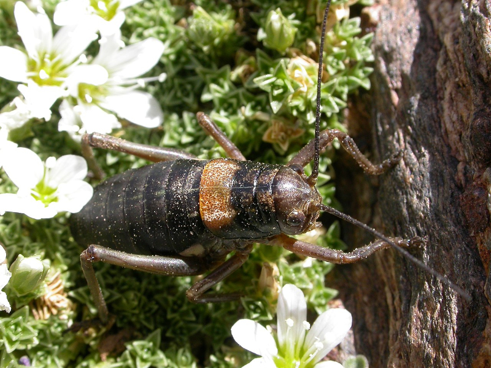

*Baetica ustulata* cubierto de polen. De [wikipedia.es](https://es.wikipedia.org/wiki/Baetica_ustulata)

# Análisis de datos

## Diversidad a distintas alturas de Sierra Nevada

Usamos unos datos recogidos en diferentes parcelas de Sierra Nevada, situadas a distintas alturas. En cada parcela se anotan el número de especies de fauna y flora identificadas.

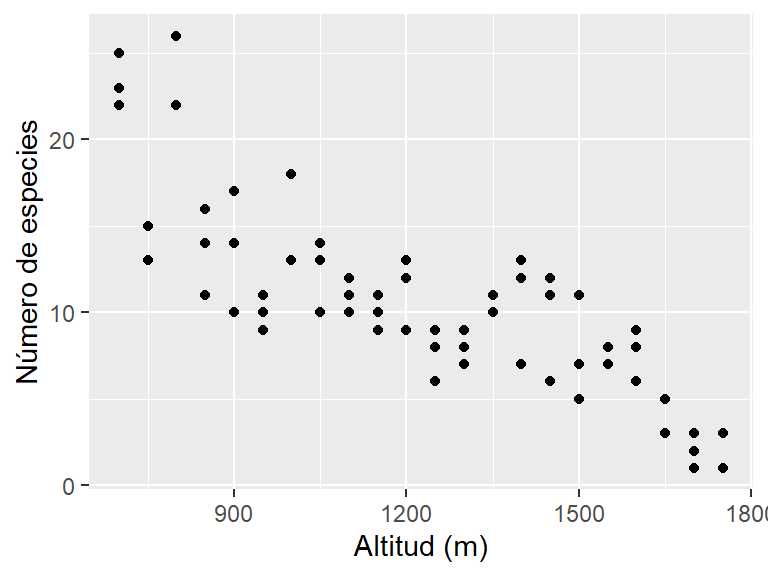

Diversidad de especies en Sierra Nevada por altitud

## Datos climáticos de Sierra Nevada

En Sierra Nevada la temperatura oscila drásticamente a lo largo de las estaciones. En este estudio hemos realizado toma de datos de la temperatura media mensual, la precipitación mensual y la evapotranspiración potencial mensual en diferentes parcelas de Sierra Nevada. Estas parcelas están seleccionadas según el tipo de vegetación presente y la altura a la que se encuentran.

## Temperatura media anual en cada parcela

Temperatura media anual por especie

| especie | temperatura |
| --- | --- |
| P. halepensis | 13.60495 |
| P. nigra | 10.93139 |
| P. pinaster | 11.53559 |
| P. sylvestris | 10.19061 |

Temperatura media anual por sitio

| especie | temperatura |
| --- | --- |
| High | 10.66097 |
| Medium | 11.65184 |
| Low | 12.38409 |

## Precipitación en cada parcela según sitio y según especie

Precipitación media anual por especie

| especie | precipitacion | sd |
| --- | --- | --- |
| P. halepensis | 20.36027 | 26.65945 |
| P. nigra | 27.88081 | 33.04996 |
| P. pinaster | 29.5486 | 35.8335 |
| P. sylvestris | 53.62145 | 74.06329 |

Precipitación media anual por sitio

| sitio | precipitacion | sd |
| --- | --- | --- |
| High | 35.11597 | 49.4455 |
| Medium | 32.16149 | 47.60501 |
| Low | 31.28089 | 46.65578 |

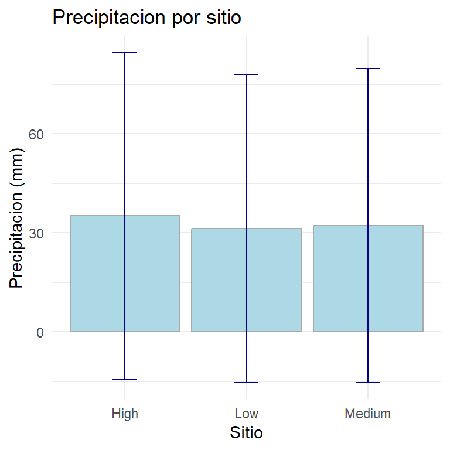

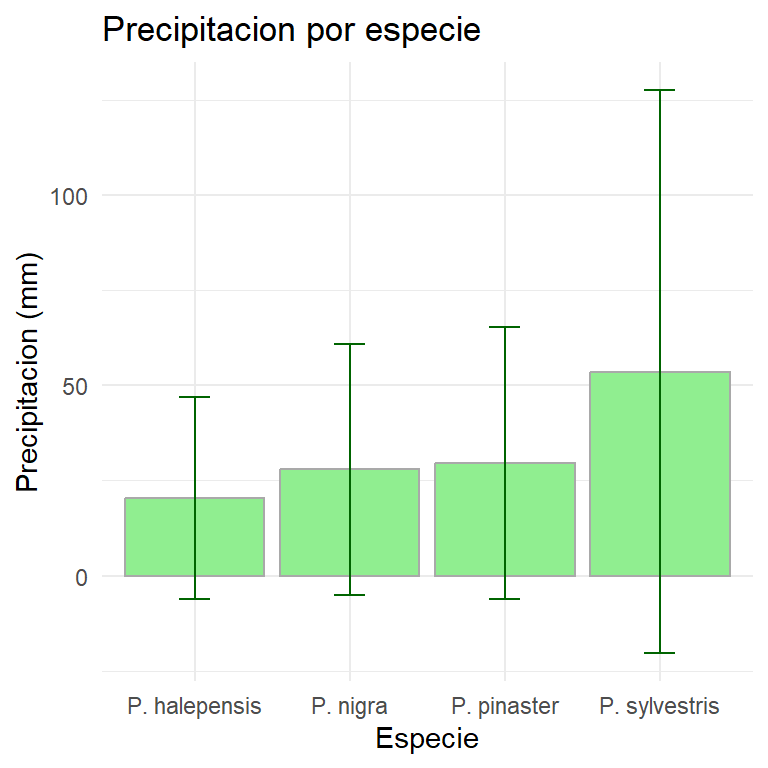

# Bibliografía

Blanca, G., Cueto, M., Martínez-Lirola, M. J., & Molero-Mesa, J. (1998). Threatened vascular flora of Sierra Nevada (Southern Spain). *Biological Conservation*, *85*(3), 269–285. https://doi.org/10.1016/S0006-3207(97)00169-9

Tinaut, A., Aguayo, D., Pascual, F., Ruano, F., Sandoval, P., & Tierno De Figueroa, J. M. (2024). Artrópodos endémicos de Sierra Nevada (España): Actualización de su estatus. *Suplementos Del Boletín de La Asociación Española de Entomología*, *7*, 1–63. https://doi.org/10.70186/sbaeeTLRL4606